# Caso práctico 4: Generación de mapas de precipitación mediante técnicas de co-krigeado

Predicción co-kriging usando la librería gstat

#### Install packages.

```r
# install.packages("maptools")
# install.packages("rgdal")
# install.packages("raster")
# install.packages("classInt")
# install.packages("RColorBrewer")
# install.packages("gstat")
```

#### Load packages.

```r
library(maptools)
library(rgdal)
library(raster)
library(classInt)
library(RColorBrewer)
library(gstat)
```

#### Set working directory

Note that in R the bar of a path is /, while in Windows it is the counterbar.

```r
#setwd("../caso_practico_4/")
setwd("C:/GABRIEL_20192301/DOCTORADO/Asignaturas-docencia/GEOESTADISTICA")
```

#### Loading the observations

Loading the shape point file which contains the observed data.

```r
dat <- readShapePoints("Datos_cp4/precip_seasonal.shp")
str(dat)
```

```
## Formal class 'SpatialPointsDataFrame' [package "sp"] with 5 slots
##   ..@ data       :'data.frame':  212 obs. of  16 variables:
##   .. ..$ INDICATIU : Factor w/ 212 levels "E7029","E7031",..: 1 2 3 4 5 6 7 8 9 10 ...
##   .. ..$ ESTACIO   : Factor w/ 212 levels "AGOST  ESCUELA NACIONAL",..: 173 125 143 109 20 108 93 101 163 80 ...
##   .. ..$ ALTITUD   : int [1:212] 203 2 45 1 40 2 60 502 36 90 ...
##   .. ..$ X         : num [1:212] 680954 693537 695385 701067 695181 ...
##   .. ..$ Y         : num [1:212] 4195707 4184490 4195298 4205830 4211023 ...
##   .. ..$ PROVINCIA : Factor w/ 8 levels "ALBACETE","ALICANTE",..: 5 5 2 2 2 2 2 5 5 5 ...
##   .. ..$ MesosCompl: int [1:212] 549 552 343 552 401 550 402 451 551 477 ...
##   .. ..$ MesosNoCom: int [1:212] 3 0 209 0 151 2 150 101 1 75 ...
##   .. ..$ AnysComple: int [1:212] 43 46 22 46 31 44 28 35 45 36 ...
##   .. ..$ AnysIncomp: int [1:212] 3 0 9 0 4 2 7 3 1 6 ...
##   .. ..$ AnysBuits : int [1:212] 0 0 15 0 11 0 11 8 0 4 ...
##   .. ..$ spring    : num [1:212] 78.9 76.5 74.7 61.9 80 ...
##   .. ..$ summer    : num [1:212] 25 23.8 20.6 17.7 19.8 ...
##   .. ..$ autumn    : num [1:212] 99.6 119.7 109.3 101.6 116.7 ...
##   .. ..$ winter    : num [1:212] 83.6 93.9 89.9 75.4 85 ...
##   .. ..$ annual    : num [1:212] 287 314 295 257 301 ...
##   .. ..- attr(*, "data_types")= chr [1:16] "C" "C" "N" "F" ...
##   ..@ coords.nrs : num(0)
##   ..@ coords     : num [1:212, 1:2] 680954 693537 695385 701067 695181 ...
##   .. ..- attr(*, "dimnames")=List of 2
##   .. .. ..$ : chr [1:212] "0" "1" "2" "3" ...
##   .. .. ..$ : chr [1:2] "coords.x1" "coords.x2"
##   ..@ bbox       : num [1:2, 1:2] 603884 4184490 814056 4532311
##   .. ..- attr(*, "dimnames")=List of 2
##   .. .. ..$ : chr [1:2] "coords.x1" "coords.x2"
##   .. .. ..$ : chr [1:2] "min" "max"
##   ..@ proj4string:Formal class 'CRS' [package "sp"] with 1 slot
##   .. .. ..@ projargs: chr NA
```

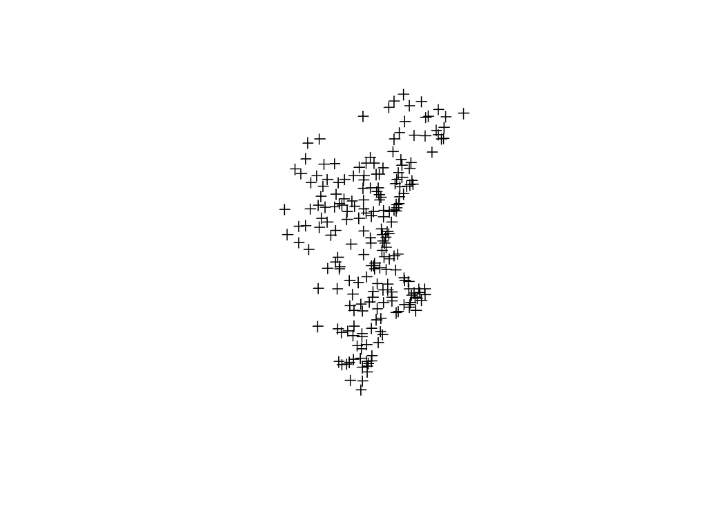

```r
plot(dat)
```

#### Loading the Valencian Community (VC) administrative boundaries

Loading the shape polygons file which contains the border of the Valencian Community.

```r
lim_cv <- readShapePoly("Datos_cp4/cv.shp")
str(lim_cv)
```

```
## Formal class 'SpatialPolygonsDataFrame' [package "sp"] with 5 slots
##   ..@ data       :'data.frame':  1 obs. of  1 variable:
##   .. ..$ PROVIN_ID: int 1
##   .. ..- attr(*, "data_types")= chr "N"
##   ..@ polygons   :List of 1
##   .. ..$ :Formal class 'Polygons' [package "sp"] with 5 slots
##   .. .. .. ..@ Polygons :List of 2
##   .. .. .. .. ..$ :Formal class 'Polygon' [package "sp"] with 5 slots
##   .. .. .. .. .. .. ..@ labpt  : num [1:2] 647997 4437991
##   .. .. .. .. .. .. ..@ area   : num 3.7e+08
##   .. .. .. .. .. .. ..@ hole   : logi FALSE
##   .. .. .. .. .. .. ..@ ringDir: int 1
##   .. .. .. .. .. .. ..@ coords : num [1:201, 1:2] 647805 648974 649215 649557 649612 ...
##   .. .. .. .. ..$ :Formal class 'Polygon' [package "sp"] with 5 slots
##   .. .. .. .. .. .. ..@ labpt  : num [1:2] 711404 4362427
##   .. .. .. .. .. .. ..@ area   : num 2.29e+10
##   .. .. .. .. .. .. ..@ hole   : logi FALSE
##   .. .. .. .. .. .. ..@ ringDir: int 1
##   .. .. .. .. .. .. ..@ coords : num [1:3291, 1:2] 741050 740996 740864 740933 741112 ...
##   .. .. .. ..@ plotOrder: int [1:2] 2 1
##   .. .. .. ..@ labpt    : num [1:2] 711404 4362427
##   .. .. .. ..@ ID       : chr "0"
##   .. .. .. ..@ area     : num 2.33e+10
##   ..@ plotOrder  : int 1
##   ..@ bbox       : num [1:2, 1:2] 626680 4191040 797835 4519371
##   .. ..- attr(*, "dimnames")=List of 2
##   .. .. ..$ : chr [1:2] "x" "y"
##   .. .. ..$ : chr [1:2] "min" "max"
##   ..@ proj4string:Formal class 'CRS' [package "sp"] with 1 slot
##   .. .. ..@ projargs: chr NA
```

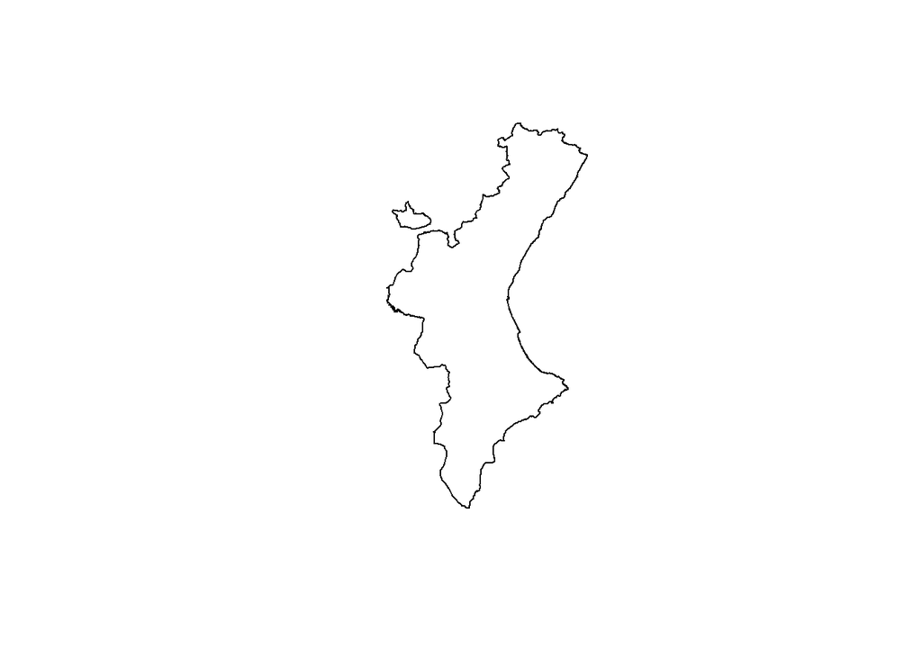

```r
plot(lim_cv)
```

#### Loading the raster file with the Digital Elevation Model (DEM)

Reading the raster file which contains DEM.

```r
ras <- raster("Datos_cp4/mde_100.tif", layer=0, values=TRUE)
str(ras)
```

```
## Formal class 'RasterLayer' [package "raster"] with 12 slots
##   ..@ file    :Formal class '.RasterFile' [package "raster"] with 13 slots
##   .. .. ..@ name        : chr "C:\\GABRIEL_20192301\\DOCTORADO\\Asignaturas-docencia\\GEOESTADISTICA\\Datos_cp4\\mde_100.tif"
##   .. .. ..@ datanotation: chr "FLT4S"
##   .. .. ..@ byteorder   : chr "little"
##   .. .. ..@ nodatavalue : num -Inf
##   .. .. ..@ NAchanged   : logi FALSE
##   .. .. ..@ nbands      : int 1
##   .. .. ..@ bandorder   : chr "BIL"
##   .. .. ..@ offset      : int 0
##   .. .. ..@ toptobottom : logi TRUE
##   .. .. ..@ blockrows   : int 128
##   .. .. ..@ blockcols   : int 128
##   .. .. ..@ driver      : chr "gdal"
##   .. .. ..@ open        : logi FALSE
##   ..@ data    :Formal class '.SingleLayerData' [package "raster"] with 13 slots
##   .. .. ..@ values    : logi(0)
##   .. .. ..@ offset    : num 0
##   .. .. ..@ gain      : num 1
##   .. .. ..@ inmemory  : logi FALSE
##   .. .. ..@ fromdisk  : logi TRUE
##   .. .. ..@ isfactor  : logi FALSE
##   .. .. ..@ attributes: list()
##   .. .. ..@ haveminmax: logi FALSE
##   .. .. ..@ min       : num Inf
##   .. .. ..@ max       : num -Inf
##   .. .. ..@ band      : int 1
##   .. .. ..@ unit      : chr ""
##   .. .. ..@ names     : chr "mde_100"
##   ..@ legend  :Formal class '.RasterLegend' [package "raster"] with 5 slots
##   .. .. ..@ type      : chr(0)
##   .. .. ..@ values    : logi(0)
##   .. .. ..@ color     : logi(0)
##   .. .. ..@ names     : logi(0)
##   .. .. ..@ colortable: logi(0)
##   ..@ title   : chr(0)
##   ..@ extent  :Formal class 'Extent' [package "raster"] with 4 slots
##   .. .. ..@ xmin: num 6e+05
##   .. .. ..@ xmax: num 839939
##   .. .. ..@ ymin: num 4149746
##   .. .. ..@ ymax: num 4549946
##   ..@ rotated : logi FALSE
##   ..@ rotation:Formal class '.Rotation' [package "raster"] with 2 slots
##   .. .. ..@ geotrans: num(0)
##   .. .. ..@ transfun:function ()
##   ..@ ncols   : int 2403
##   ..@ nrows   : int 4002
##   ..@ crs     :Formal class 'CRS' [package "sp"] with 1 slot
##   .. .. ..@ projargs: chr "+proj=utm +zone=30 +ellps=GRS80 +units=m +no_defs"
##   ..@ history : list()
##   ..@ z       : list()
```

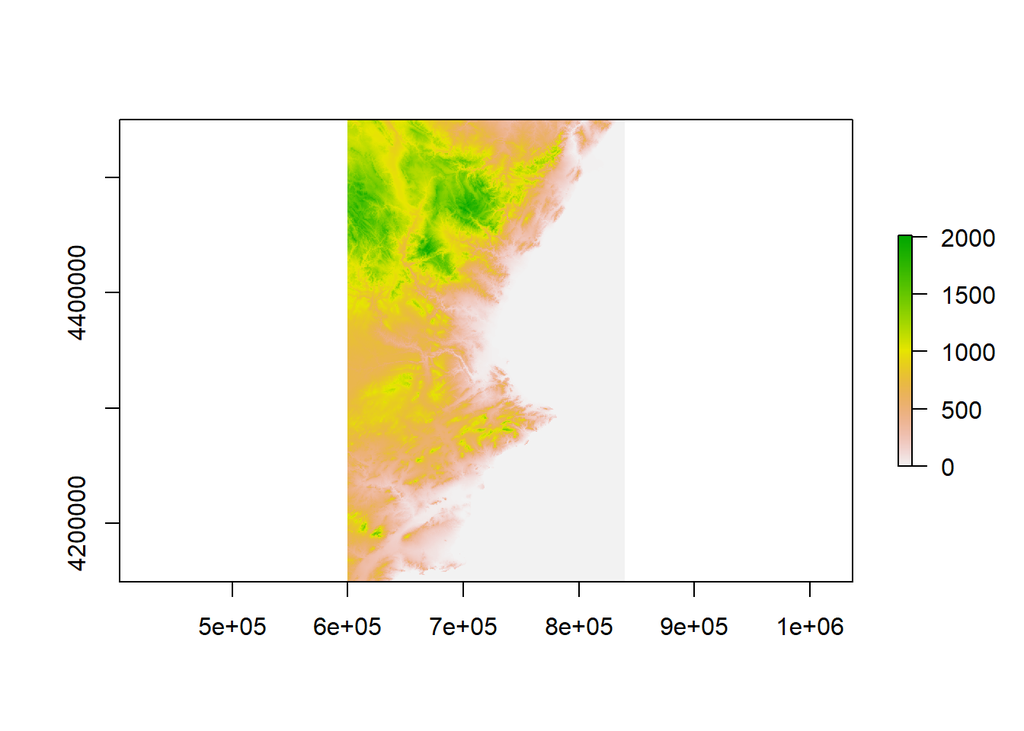

```r
plot(ras)
```

#### Obtaining the predicting locations

In order to obtain a continuous map of precipitation, we need to make punctual predictions in a dense grid of locations. In R there are different ways to define a grid. In this case, we are going to use the DEM’s raster object (‘ras’) above obtained to construct the grid of predicting locations. The collection of pixel mid points make a grid itself, so we just have to extract the mid points and their coordinates of every pixel.

First of all, in order to save computation, the spatial resolution of the raster object can be reduced. Thus, the number of points of the resulting grid will not be so large, and further computation reduced.

Finally, the grid of points will be clipped by the border of CV.

1. Reducing the spatial resolution of the raster. Reduction factor=1/16.

```r
ras <- aggregate(ras, fact=c(4,4), fun=mean)
str(ras)
```

```
## Formal class 'RasterLayer' [package "raster"] with 12 slots
##   ..@ file    :Formal class '.RasterFile' [package "raster"] with 13 slots
##   .. .. ..@ name        : chr ""
##   .. .. ..@ datanotation: chr "FLT4S"
##   .. .. ..@ byteorder   : chr "little"
##   .. .. ..@ nodatavalue : num -Inf
##   .. .. ..@ NAchanged   : logi FALSE
##   .. .. ..@ nbands      : int 1
##   .. .. ..@ bandorder   : chr "BIL"
##   .. .. ..@ offset      : int 0
##   .. .. ..@ toptobottom : logi TRUE
##   .. .. ..@ blockrows   : int 128
##   .. .. ..@ blockcols   : int 128
##   .. .. ..@ driver      : chr ""
##   .. .. ..@ open        : logi FALSE
##   ..@ data    :Formal class '.SingleLayerData' [package "raster"] with 13 slots
##   .. .. ..@ values    : num [1:601601] 805 794 774 743 765 ...
##   .. .. ..@ offset    : num 0
##   .. .. ..@ gain      : num 1
##   .. .. ..@ inmemory  : logi TRUE
##   .. .. ..@ fromdisk  : logi FALSE
##   .. .. ..@ isfactor  : logi FALSE
##   .. .. ..@ attributes: list()
##   .. .. ..@ haveminmax: logi TRUE
##   .. .. ..@ min       : num 0
##   .. .. ..@ max       : num 2003
##   .. .. ..@ band      : int 1
##   .. .. ..@ unit      : chr ""
##   .. .. ..@ names     : chr "mde_100"
##   ..@ legend  :Formal class '.RasterLegend' [package "raster"] with 5 slots
##   .. .. ..@ type      : chr(0)
##   .. .. ..@ values    : logi(0)
##   .. .. ..@ color     : logi(0)
##   .. .. ..@ names     : logi(0)
##   .. .. ..@ colortable: logi(0)
##   ..@ title   : chr(0)
##   ..@ extent  :Formal class 'Extent' [package "raster"] with 4 slots
##   .. .. ..@ xmin: num 6e+05
##   .. .. ..@ xmax: num 840039
##   .. .. ..@ ymin: num 4149546
##   .. .. ..@ ymax: num 4549946
##   ..@ rotated : logi FALSE
##   ..@ rotation:Formal class '.Rotation' [package "raster"] with 2 slots
##   .. .. ..@ geotrans: num(0)
##   .. .. ..@ transfun:function ()
##   ..@ ncols   : int 601
##   ..@ nrows   : int 1001
##   ..@ crs     :Formal class 'CRS' [package "sp"] with 1 slot
##   .. .. ..@ projargs: chr "+proj=utm +zone=30 +ellps=GRS80 +units=m +no_defs"
##   ..@ history : list()
##   ..@ z       : list()
```

2. Converting the raster to a SpatialPoints, thus obtaing the grid of predicting points, stored in the new object ‘loc’.

```r
loc <- rasterToPoints(ras, fun=NULL, spatial=TRUE)
str(loc)
```

```
## Formal class 'SpatialPointsDataFrame' [package "sp"] with 5 slots
##   ..@ data       :'data.frame':  601601 obs. of  1 variable:
##   .. ..$ mde_100: num [1:601601] 805 794 774 743 765 ...
##   ..@ coords.nrs : num(0)
##   ..@ coords     : num [1:601601, 1:2] 599839 600239 600639 601039 601439 ...
##   .. ..- attr(*, "dimnames")=List of 2
##   .. .. ..$ : NULL
##   .. .. ..$ : chr [1:2] "x" "y"
##   ..@ bbox       : num [1:2, 1:2] 599839 4149746 839839 4549746
##   .. ..- attr(*, "dimnames")=List of 2
##   .. .. ..$ : chr [1:2] "x" "y"
##   .. .. ..$ : chr [1:2] "min" "max"
##   ..@ proj4string:Formal class 'CRS' [package "sp"] with 1 slot
##   .. .. ..@ projargs: chr "+proj=utm +zone=30 +ellps=GRS80 +units=m +no_defs"
```

3. Cliping the object ‘loc’ by the VC boundary. The resulting object ‘loc’ will be used as prediction locations.

```r
loc <- crop(loc, lim_cv)
str(loc)
```

```
## Formal class 'SpatialPointsDataFrame' [package "sp"] with 5 slots
##   ..@ data       :'data.frame':  145434 obs. of  1 variable:
##   .. ..$ mde_100: num [1:145434] 747 831 864 848 800 ...
##   ..@ coords.nrs : num(0)
##   ..@ coords     : num [1:145434, 1:2] 739439 738239 738639 739039 739439 ...
##   .. ..- attr(*, "dimnames")=List of 2
##   .. .. ..$ : NULL
##   .. .. ..$ : chr [1:2] "x" "y"
##   ..@ bbox       : num [1:2, 1:2] 627039 4191346 797439 4519346
##   .. ..- attr(*, "dimnames")=List of 2
##   .. .. ..$ : chr [1:2] "x" "y"
##   .. .. ..$ : chr [1:2] "min" "max"
##   ..@ proj4string:Formal class 'CRS' [package "sp"] with 1 slot
##   .. .. ..@ projargs: chr "+proj=utm +zone=30 +ellps=GRS80 +units=m +no_defs"
```

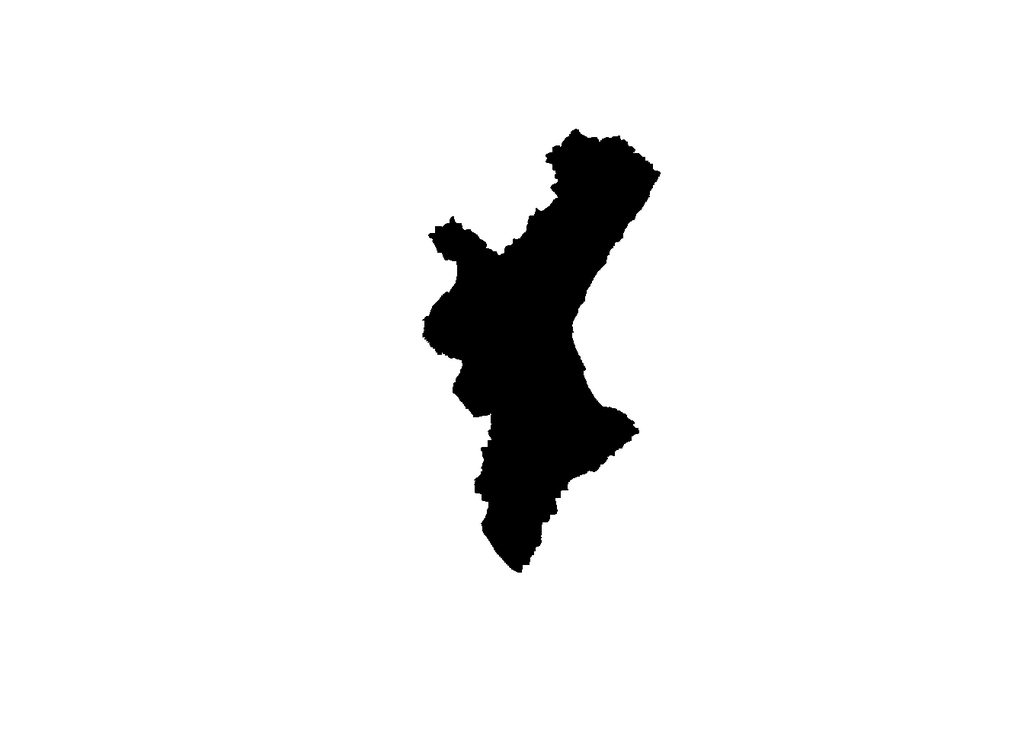

```r
plot(loc)
```

#### Coordinate scaling

With the ‘gstat’ library it does not need to standardize the XY coordinates unlike the previously used library ‘geoR’ in the kriging model. So, we use the original units for the X and Y coordinates of both objects ‘dat’ and ‘loc’.

#### Reference coordinate system

Set the reference coordinate system for the object ‘dat’, making it equal to that in the object ‘loc’.

```r
proj4string(dat) <- loc@proj4string@projargs
str(dat)
```

```
## Formal class 'SpatialPointsDataFrame' [package "sp"] with 5 slots
##   ..@ data       :'data.frame':  212 obs. of  16 variables:
##   .. ..$ INDICATIU : Factor w/ 212 levels "E7029","E7031",..: 1 2 3 4 5 6 7 8 9 10 ...
##   .. ..$ ESTACIO   : Factor w/ 212 levels "AGOST  ESCUELA NACIONAL",..: 173 125 143 109 20 108 93 101 163 80 ...
##   .. ..$ ALTITUD   : int [1:212] 203 2 45 1 40 2 60 502 36 90 ...
##   .. ..$ X         : num [1:212] 680954 693537 695385 701067 695181 ...
##   .. ..$ Y         : num [1:212] 4195707 4184490 4195298 4205830 4211023 ...
##   .. ..$ PROVINCIA : Factor w/ 8 levels "ALBACETE","ALICANTE",..: 5 5 2 2 2 2 2 5 5 5 ...
##   .. ..$ MesosCompl: int [1:212] 549 552 343 552 401 550 402 451 551 477 ...
##   .. ..$ MesosNoCom: int [1:212] 3 0 209 0 151 2 150 101 1 75 ...
##   .. ..$ AnysComple: int [1:212] 43 46 22 46 31 44 28 35 45 36 ...
##   .. ..$ AnysIncomp: int [1:212] 3 0 9 0 4 2 7 3 1 6 ...
##   .. ..$ AnysBuits : int [1:212] 0 0 15 0 11 0 11 8 0 4 ...
##   .. ..$ spring    : num [1:212] 78.9 76.5 74.7 61.9 80 ...
##   .. ..$ summer    : num [1:212] 25 23.8 20.6 17.7 19.8 ...
##   .. ..$ autumn    : num [1:212] 99.6 119.7 109.3 101.6 116.7 ...
##   .. ..$ winter    : num [1:212] 83.6 93.9 89.9 75.4 85 ...
##   .. ..$ annual    : num [1:212] 287 314 295 257 301 ...
##   .. ..- attr(*, "data_types")= chr [1:16] "C" "C" "N" "F" ...
##   ..@ coords.nrs : num(0)
##   ..@ coords     : num [1:212, 1:2] 680954 693537 695385 701067 695181 ...
##   .. ..- attr(*, "dimnames")=List of 2
##   .. .. ..$ : chr [1:212] "0" "1" "2" "3" ...
##   .. .. ..$ : chr [1:2] "coords.x1" "coords.x2"
##   ..@ bbox       : num [1:2, 1:2] 603884 4184490 814056 4532311
##   .. ..- attr(*, "dimnames")=List of 2
##   .. .. ..$ : chr [1:2] "coords.x1" "coords.x2"
##   .. .. ..$ : chr [1:2] "min" "max"
##   ..@ proj4string:Formal class 'CRS' [package "sp"] with 1 slot
##   .. .. ..@ projargs: chr "+proj=utm +zone=30 +ellps=GRS80 +units=m +no_defs"
```

#### Initialization of the object ‘gstat’:

Recursive creation of the object ‘g’ containing the information for the co-kriging model. First, we define it with the information of the variable ‘spring’ and then with the information of the variable ‘ALTITUD’. The global tendency is specified by the parameter ‘form’ (form = spring ~ X*Y). If we do not use tendency in our model, the parameter ‘form’ must be set to ‘form = spring ~ 1’. The parameter ‘data’ speficies the actual data.

```r
g <- gstat(NULL, form= spring ~ X*Y, locations= ~X+Y, data=dat@data)
g <- gstat(g, form= ALTITUD ~ X*Y, locations= ~X+Y, data=dat@data)
(g)
```

```
## data:
## var1 : formula = spring`~`X * Y ; data dim = 212 x 14
## var2 : formula = ALTITUD`~`X * Y ; data dim = 212 x 14
## ~X + Y
```

#### Empiric and analytic variogram of the first variable

Empiric variogram with tendency.

[figure not shown]

```r
varig_1 <- variogram(spring ~ X*Y, locations= ~X+Y, data=dat@data)

plot(varig_1, pl=T, main="winter")
```

Fit an analytical function for the variogram.

```r
fit_varig_1 <- fit.variogram(varig_1, model= vgm(200,"Sph",80000,20), fit.method= 6)
(fit_varig_1)
```

```
##   model    psill    range
## 1   Nug 134.1796      0.0
## 2   Sph 777.0510 112353.2
```

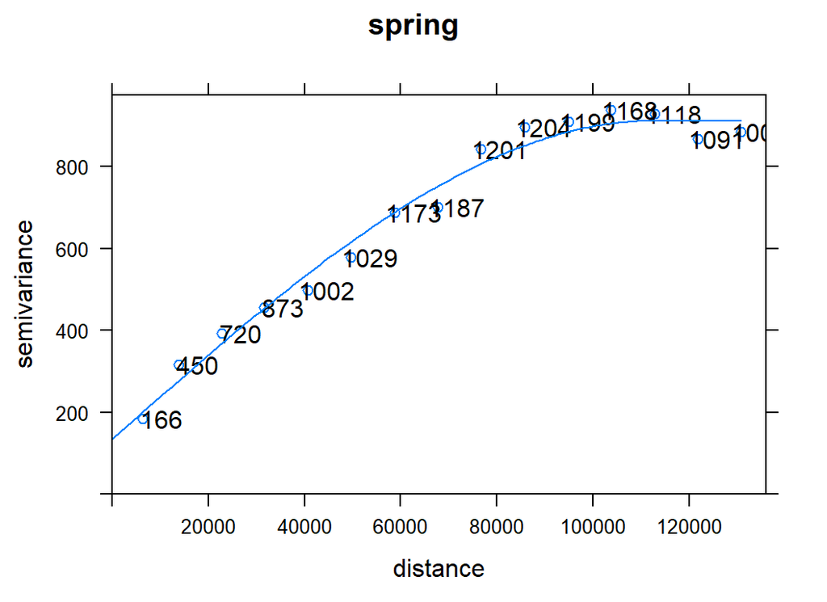

```r
plot(varig_1, pl=T, model=fit_varig_1, main="spring")
```

#### Empiric and analytic variogram of the second variable

Empiric variogram with tendency.

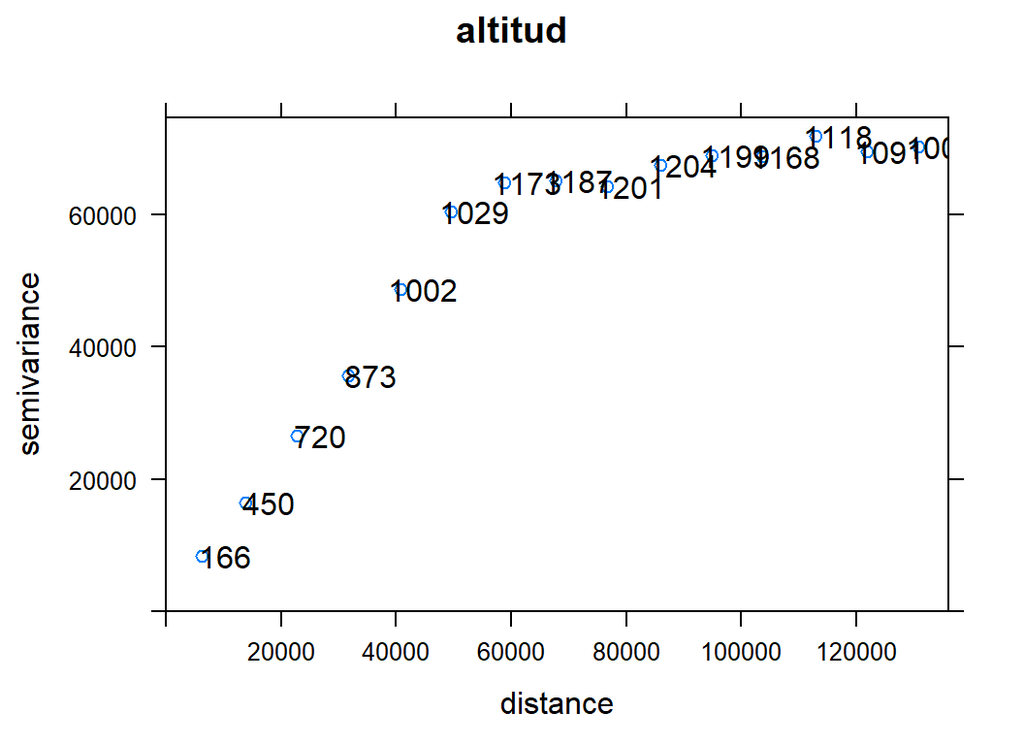

```r
varig_2 <- variogram(ALTITUD ~ X*Y, locations= ~X+Y, data=dat@data)

plot(varig_2, pl=T, main="altitud")
```

Fit an analytical function for the variogram.

```r
fit_varig_2 <- fit.variogram(varig_2, model= vgm(60000,"Gau",50000,5000),fit.sills = TRUE, fit.ranges = TRUE, fit.method = 7, debug.level = 1, warn.if.neg = TRUE, fit.kappa = FALSE)
(fit_varig_2)
```

```
##   model     psill    range
## 1   Nug  7195.274     0.00
## 2   Gau 61185.589 37469.85
```

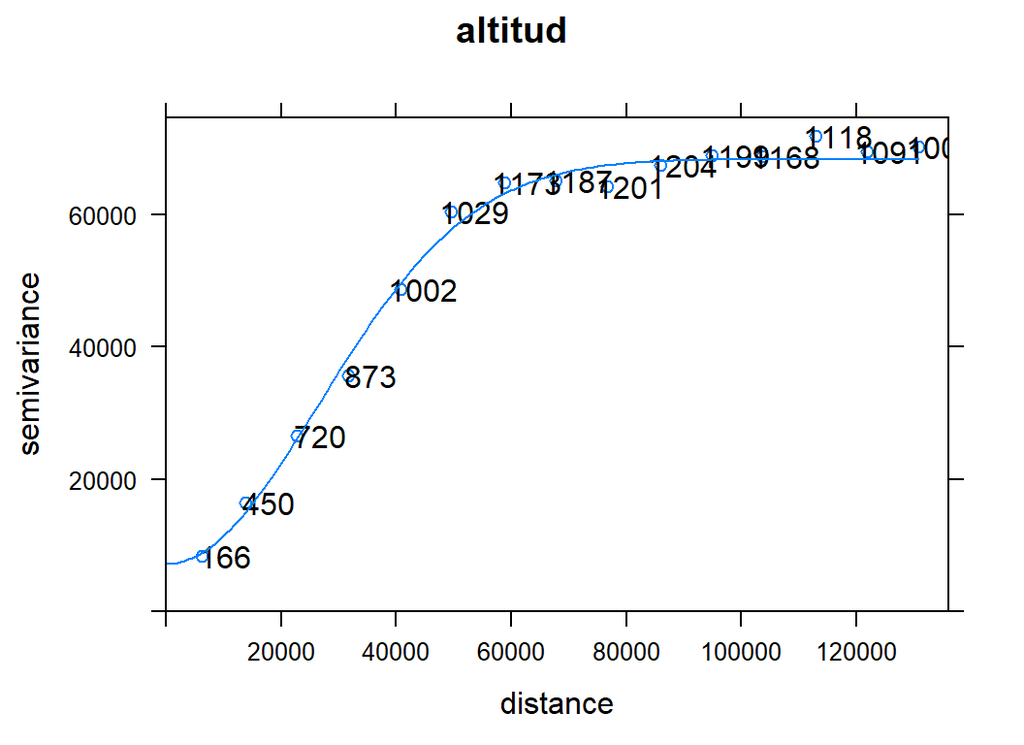

```r
plot(varig_2, pl=T, model=fit_varig_2, main="altitud")
```

#### Cross variogram

Joint specification of both individual and cross variograms by using the same variogram model for both.

```r
g <- gstat(g, id= "spring", model= fit_varig_2 , fill.all= T)
(g)
```

```
## data:
## var1 : formula = spring`~`X * Y ; data dim = 212 x 14
## var2 : formula = ALTITUD`~`X * Y ; data dim = 212 x 14
## variograms:
##              model     psill    range
## var1[1]        Nug  7195.274     0.00
## var1[2]        Gau 61185.589 37469.85
## var2[1]        Nug  7195.274     0.00
## var2[2]        Gau 61185.589 37469.85
## var1.var2[1]   Nug  7195.274     0.00
## var1.var2[2]   Gau 61185.589 37469.85
## ~X + Y
```

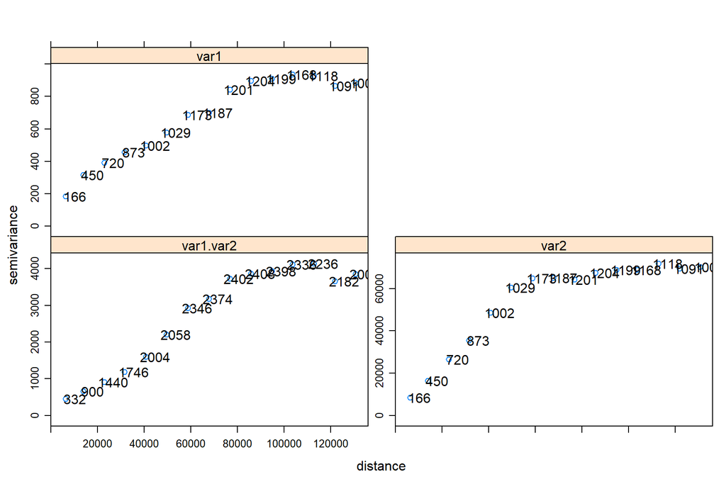

```r
plot(variogram(g), pl=T)
```

Cross variogram

```r
varig.cross <- variogram(g)
```

Fit an analytical function for both individual and cross variograms.

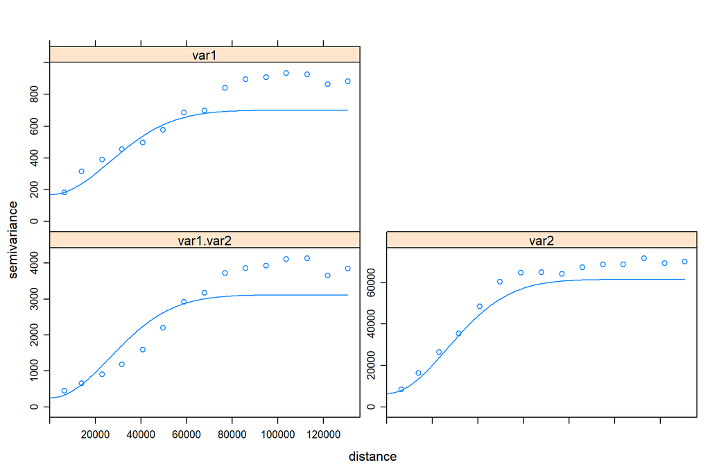

```r
g <- fit.lmc(varig.cross, g, fit.method = 7, fit.ranges = FALSE, fit.lmc = TRUE, correct.diagonal = 0.90)

plot(variogram(g), model= g$model)
```

#### Co-krigin prediction

we need to have the same names for variables in both objects ‘dat’ and ‘loc’.

```r
loc@data$ALTITUD <- loc@data$mde_100
loc@data$X <- loc@coords[,1]
loc@data$Y <- loc@coords[,2]
```

Co-kriging function

```r
kc <- predict(g, newdata=loc@data)
```

```
## Linear Model of Coregionalization found. Good.
## [using universal cokriging]
```

```r
str(kc)
```

```
## 'data.frame':    145434 obs. of  7 variables:
##  $ X            : num  739439 738239 738639 739039 739439 ...
##  $ Y            : num  4519346 4518946 4518946 4518946 4518946 ...
##  $ var1.pred    : num  136 135 135 136 136 ...
##  $ var1.var     : num  214 214 214 214 214 ...
##  $ var2.pred    : num  712 710 713 716 719 ...
##  $ var2.var     : num  8681 8702 8704 8707 8711 ...
##  $ cov.var1.var2: num  350 351 351 351 352 ...
```

```r
loc@data$predict <- kc$var1.pred   #predictions
loc@data$predict.sd <- sqrt(kc$var1.var)   #predicting errors
```

Histograms

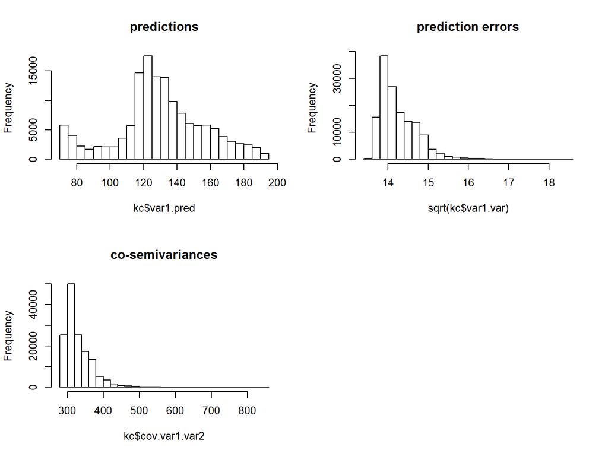

```r
par(mfrow=c(2,2))

hist(kc$var1.pred, breaks=30, main="predictions")
hist(sqrt(kc$var1.var), breaks=30, main="prediction errors")
hist(kc$cov.var1.var2, breaks=30, main="co-semivariances")
```

#### Cross-validation:

Cross-validation

```r
kc.cv <- gstat.cv(g, remove.all = FALSE, all.residuals = FALSE, maxdist=150000, nmax=150, nfold= 30)
```

[output not shown]

```r
str(kc.cv)
```

```
## 'data.frame':    212 obs. of  8 variables:
##  $ var1.pred: num  84.2 73.4 74.1 73 71.9 ...
##  $ var1.var : num  243 288 208 194 183 ...
##  $ observed : num  78.9 76.5 74.7 61.9 80 ...
##  $ residual : num  -5.27 3.114 0.613 -11.023 8.031 ...
##  $ zscore   : num  -0.3383 0.1833 0.0425 -0.7915 0.5941 ...
##  $ fold     : int  4 1 13 7 29 5 5 4 8 8 ...
##  $ X        : num  680954 693537 695385 701067 695181 ...
##  $ Y        : num  4195707 4184490 4195298 4205830 4211023 ...
```

Histograms

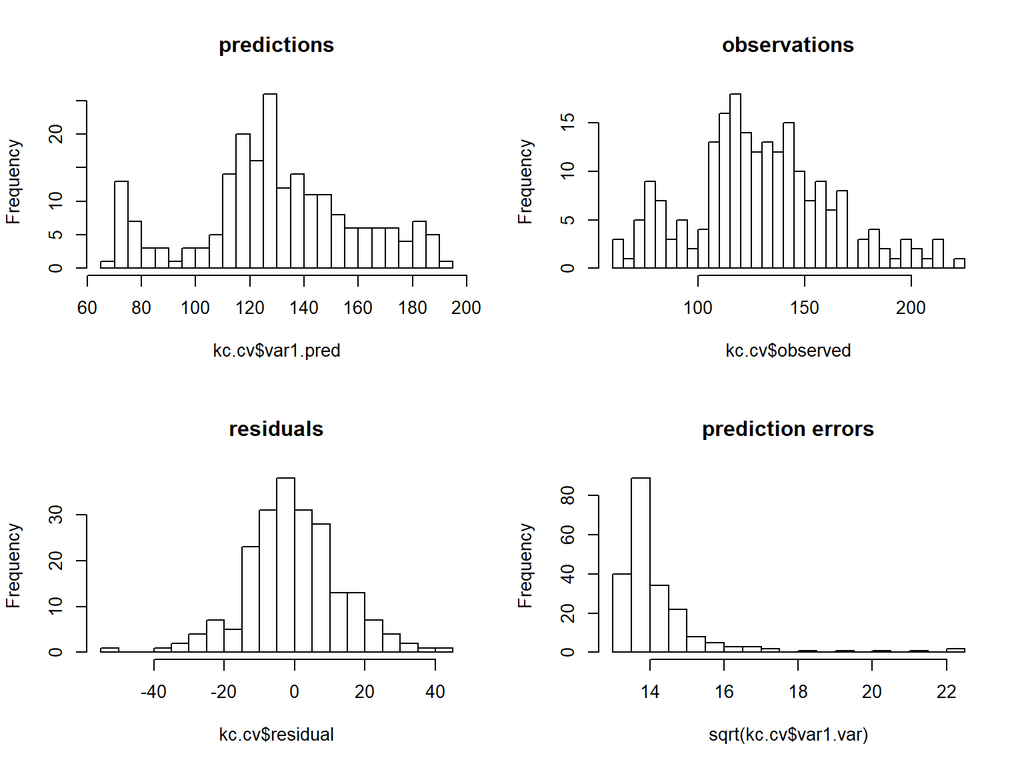

```r
par(mfrow=c(2,2))

hist(kc.cv$var1.pred, breaks=30, main="predictions")
hist(kc.cv$observed, breaks=30, main="observations")
hist(kc.cv$residual, breaks=30, main="residuals")
hist(sqrt(kc.cv$var1.var), breaks=30, main="prediction errors")
```

Plots

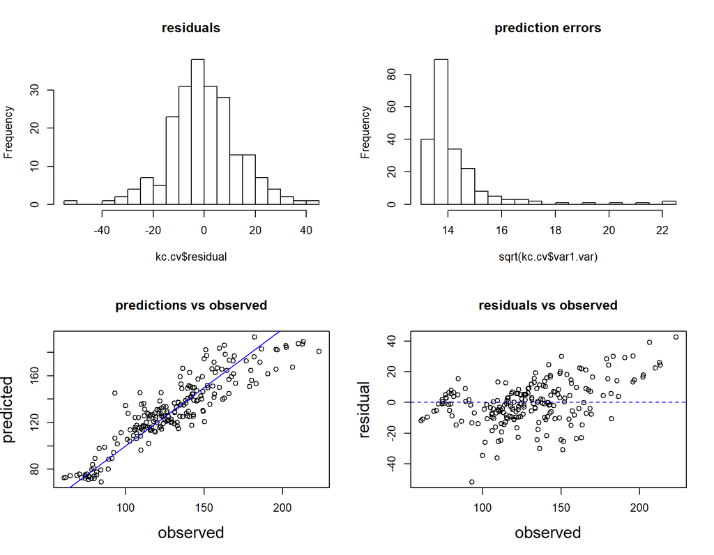

```r
par(mfrow=c(2,2))

hist(kc.cv$residual, breaks=30, main="residuals")
hist(sqrt(kc.cv$var1.var), breaks=30, main="prediction errors")
plot(kc.cv$observed, kc.cv$var1.pred, xlab="observed", ylab="predicted", cex.lab=1.5, main="predictions vs observed")
abline(a=0, b=1, col="blue", lty=1, lwd=1)
plot(kc.cv$observed, kc.cv$residual, xlab="observed", ylab="residual", cex.lab=1.5, main="residuals vs observed")
abline(h=0, col="blue", lty=2)
```

#### Map of co-kriging prediction:

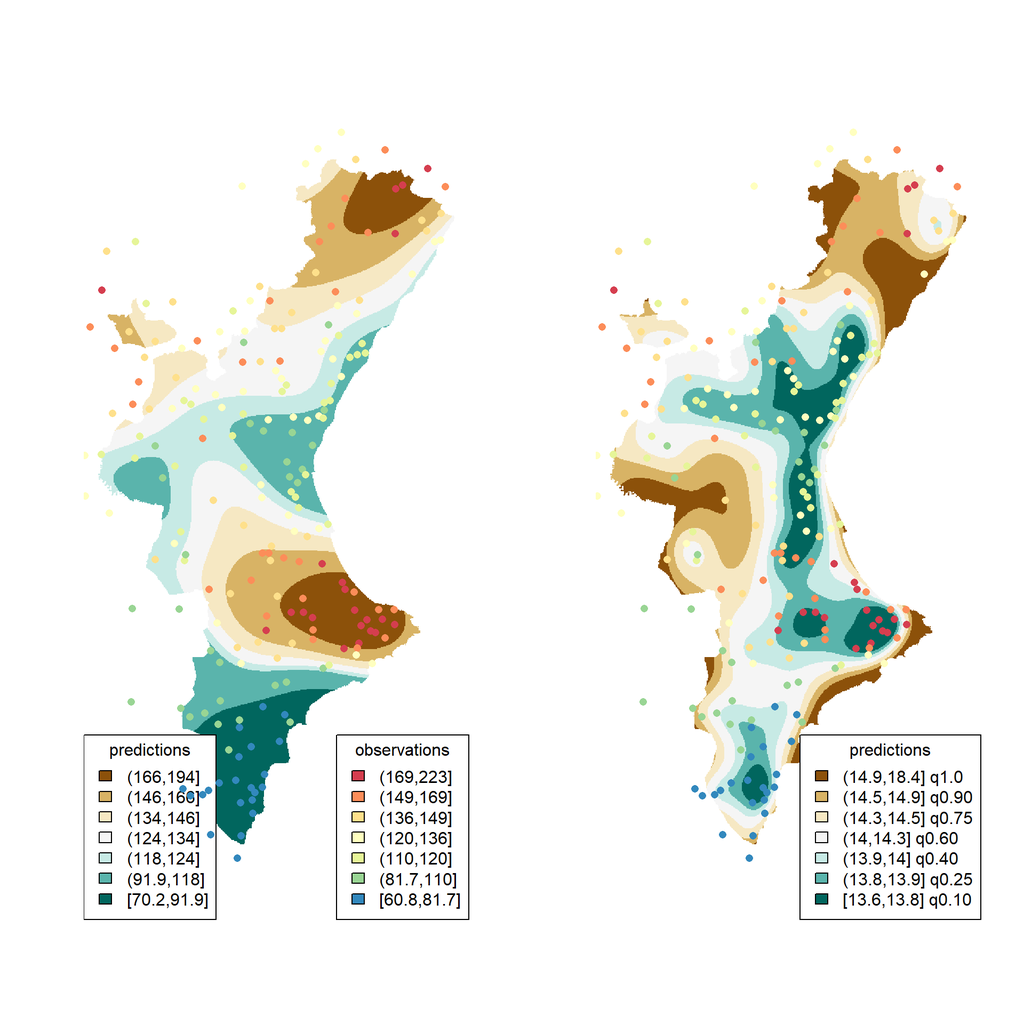

```r
par(mfrow=c(1,2))

# Predictions

loc1 <- loc
loc1$predict <- SpatialPixelsDataFrame(loc@coords, data=as.data.frame(loc@data$predict))
q5 <- quantile(loc1$predict@data[,1], c(0,0.10,0.25,0.40,0.60,0.75,0.90,1))
image(loc1$predict, col=brewer.pal(7,"BrBG")[7:1], asp=1, breaks=q5)

# Legend

br5 <- cut(loc1$predict@data[,1], breaks=q5, include.lowest=TRUE)
legend("bottomleft", legend=levels(br5)[7:1], fill=brewer.pal(7,"BrBG")[1:7], title= "predictions", cex=1)

# Observed data

q6 <- quantile(dat@data$spring, c(0,0.10,0.25,0.40,0.60,0.75,0.90,1))
br6 <- cut(dat@data$spring, breaks=q6, include.lowest=TRUE)
points(dat@coords[,1], dat@coords[,2], col=brewer.pal(7,"Spectral")[7:1][br6], asp=1, pch=16)
legend("bottomright", legend=levels(br6)[7:1], fill=brewer.pal(7,"Spectral")[1:7], title= "observations", cex=1)

# Predicting errors

loc1$predict.sd <- SpatialPixelsDataFrame(loc@coords, data=as.data.frame(loc@data$predict.sd))
q7 <- quantile(loc1$predict.sd@data[,1], c(0,0.10,0.25,0.40,0.60,0.75,0.90,1))
image(loc1$predict.sd, col=brewer.pal(7,"BrBG")[7:1], asp=1, breaks=q7)

# Legend

br7 <- cut(loc1$predict.sd@data[,1], breaks=q7, include.lowest=TRUE)
legend("bottomright", legend=paste(levels(br7)[7:1],c("q0.10","q0.25","q0.40","q0.60","q0.75","q0.90","q1.0")[7:1]), fill=brewer.pal(7,"BrBG")[1:7], title= "predictions", cex=1)

# Observed points

points(dat@coords[,1], dat@coords[,2], col=brewer.pal(7,"Spectral")[7:1][br6], asp=1, pch=16)
```